# Data Analysis

City of Golden Valley Prosecution Data

Tony Blonigan

As a part of an equity review, the city of Golden Valley requested the law firm contracted to prosecute several categories of offenses on their behalf, Chestnut Cambronne (CC), provide:

A [summary document](https://www.goldenvalleymn.gov/council/pdf/Manager-Agendas/2021/council-manager-agenda-july-13-21.pdf) is posted on their website.

## Low Level Driving Offenses

One of the data sets provided by Chestnut Cabronne is a summary of low level driving offences, which include prosecutions for the following offences:

- No driver’s license
- No proof of insurance
- No insurance
- Driving after suspension, revocation, or cancellation
- Expired tabs
- Expired driver’s license
- Window tint
- Rear view mirror obstruction
- Unsafe equipment

### Chestnut Cambronne Prosecution Dispositions by Race (01/2020 - 06/2021)

Description from Chestnut Cambronne report:

> "In total, there were 1105 cases prosecuted by the Golden Valley City Attorney that resulted in a conviction on charges of No driver’s license; no proof of insurance; no insurance; driving after suspension, revocation, or cancellation; expired tabs; expired driver’s license; window tint; rear view mirror obstruction; and unsafe equipment between January 2020 and June 2021.

> “Of these 1105 cases, 36% of the individuals identify as Black/African American, 15% identify as White, 6% identify as Hispanic/Latino, 2% identify as Multiracial, 1% identify as Native American, 1% identify as some other race, 1% identify as Asian, while we do not have race data for 38% (many of these cases are payables and will not have a court appearance, which is where race data is collected by the courts).”

Chestnut Cambronne’s full data set for low level driving offenses:

```
##                       Convicted Interim.Disposition Dismissed No.Disposition
## White                        64                   1        29             73
## Black                        73                   3        43            276
## Multiracial                   2                   1         0             17
## Asian                         3                   1         1              7
## Indian Alaskan Native         2                   0         1              7
## Some Other Race               3                   1         5              7
## Hispanic                     25                   3         9             32
## Unavailable                 196                   1        29            190
```

#### Count of Prosecutions by Race

```
##                 White                 Black           Multiracial
##                   167                   395                    20
##                 Asian Indian Alaskan Native       Some Other Race
##                    12                    10                    16
##              Hispanic           Unavailable
##                    69                   416
```

#### Percent of Prosecutions by Race

```
##                 White                 Black           Multiracial
##                    15                    36                     2
##                 Asian Indian Alaskan Native       Some Other Race
##                     1                     1                     1
##              Hispanic           Unavailable
##                     6                    38
```

### Relationship Between Race and Prosecution

Comparing the racial composition of the low level driving offenses to the [American Communities Survey](https://stats.metc.state.mn.us/profile/detail.aspx?c=02394924) demographic data (ACS) for the Golden Valley, it is immediately apparent that the black population is represented at a much higher rate than you would expect, based on Golden Valley’s demographics, if prosecution were independent of race.

Unfortunately, there are several limitations to the available data preventing a proper statistical analysis of this relationship, such as:

1. Racial and Ethnic categories are inconsistent between ACS and CC data sets
   - For example the ACS data set explicitly isolates Latino/a/x (even from multiracial), where the CC categories are more ambiguous. For example a Latino person from Brazil might consider themselves ‘Hispanic or Latinx’ given the ACS categories, but ‘Black’, ‘Multiracial’, or ‘Some Other Race’ given the CC options, since they have no Latino/a/x options.
2. 37% of the population in the CC data set is ‘Unavailable.’ The quote above, from the report on the Golden Valley website, indicates that these are people who did not have a court appearance. We have no reason to assume not having a court appearance is not associated with race, so we can’t just assume those people shared the same racial/ethnic distribution as the other defendants. Further, there is no similar category in the ACS data set, as the responses do not depend on a court case and there is no category for people who didn’t respond to the survey.
3. The CC data set is not a random sample of the population, while the ACS data is a random sample
4. Where the CC data set is taken ‘between, January 2020 through and June 2021,’ it is not clear whether this includes January and/or June, the ACS data is from 2015-2020 surveys. So there is some difference in the populations to be expected. Maybe someone in the city government would be able to advise whether it is a reasonable assumption that the racial/ethnic distribution of Golden Valley has not changed significantly over that period.
5. As indicated in the report, many of the people prosecuted are from cities other than Golden Valley. This point will be addressed separately, below.
6. It is also worth noting that the prosecutions data occurs during the COVID pandemic when driving patterns were likely different than the non COVID period.

While keeping these limitations in mind, it is still possible to use statistical tools to help understand how prosecution for low level driving offences appear to be related to race/ethnicity.

#### Conversion from ACS Race/Ethnicities to CC Race/Ethnicities

To compare the racial/ethnic makeup of the city to the racial/ethnic makeup of the population being prosecuted by CC, the ACS races must be mapped to the CC races. Imprecision in language used to describe race and ethnicity makes this is an imperfect process, but this is the mapping used for this analysis:

```
## [1] "White alone, non-Latinx -> White"
## [1] "Black alone, non-Latinx -> Black"
## [1] "More than one race, non-Latinx -> Multiracial"
## [1] "Asian alone, non-Latinx -> Asian"
## [1] "American Indian alone, non-Latinx -> Indian Alaskan Native"
## [1] "Some Other Race alone, non-Latinx -> Some Other Race"
## [1] "Hispanic or Latinx -> Hispanic"
```

#### Data Set

This is the data being analysed to see whether prosecution, which in this case translates to being pulled over and charged with a low-level driving offence, is associated with race/ethnicity.

```
##                       CC.Prosecutions ACS.Population
## Asian                              12            681
## Black                             395            970
## Hispanic                           69            579
## Indian Alaskan Native              10            157
## Multiracial                        20            945
## Some Other Race                    16             20
## Unavailable                       416             NA
## White                             167          19367
```

One way to think about this is to compare the proportions of people in each race in both data sets. If prosecutions for low level driving offences were independent of race we would expect the demographics of the prosecuted population to be similar between the prosecuted people and the rest of the Golden Valley population.

The Unknown category must be dropped because it doesn’t exist in the ACS data set. But if that category were not related to race, then this not to affect the distribution of races in the CC.Prosecutions data.

The plot below puts proportion of Golden Valley population on the x axis and proportion of prosecution population on the y axis. If there were no relationship between race and prosecution, you would expect the points would align closely to the dotted line. Many of the dots do align closely, however the plot shows black people make up a much higher proportion of the prosecution population than their proportion of the Golden Valley population. It also shows that the white people make up a much lower proportion of the population than they do of the Golden Valley population.

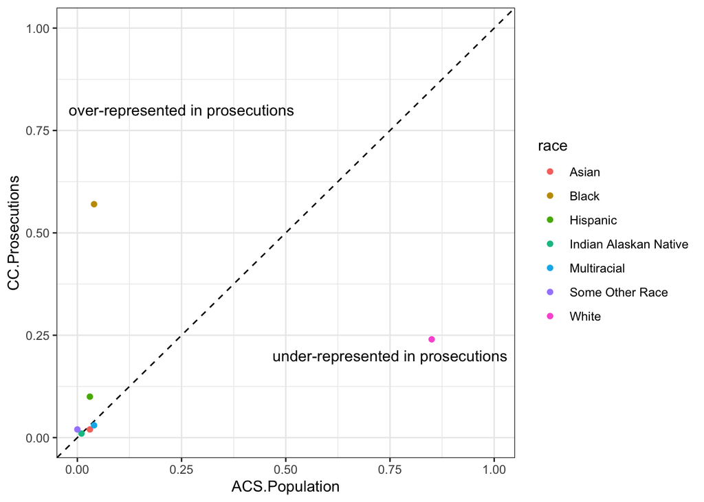

#### Chi-Square Test of Independence

In the absence of the data integrity issues enumerated, above, the chi-squared test of independence could be used to asses whether prosecution is associated with race/ethnicity. While it can’t be uses as a statistical test to determine whether there is a relationship between race and prosecution for low level driving offences, we can still use this test to highlight some concerning areas in the data.

Much like the chart above, the chi-squared test compares the actual counts of prosecutions by race to what we would expect them to be if people of all races/ethnicities were prosecuted at the same rate. The more different those two sets of counts are, the more likely prosecution is associated with race/ethnicity.

Because of the data issues listed above, the p-value, which can roughly be interpreted as the probability of seeing Golden Valley’s prosecutions counts if prosecution were independent of race/ethnicity, should not be interpreted as evidence of an association between race and prosecution for low level driving offences.

```
##
##  Pearson's Chi-squared test
##
## data:  acs_and_lld[complete.cases(acs_and_lld), ]
## X-squared = 3890, df = 6, p-value < 2.2e-16
```

#### Pearson Residual Plot

Below, is a plot that illustrates the difference between the racial/ethnic distribution of prosecutions and the racial/ethnic distribution of Golden Valley, quantified as Pearson Residuals. The length of the bars correspond to the size of the difference between the prosecution and Golden Valley populations.

The other notable bar is in the ‘Black’, ‘ACS.Population’ cell. Since the racial/ethnic distributions in both the CC and ACS data set are considered when calculating the counts of prosecutions we would expect to see if prosecution was independent of race/ethnicity, it is also possible for there to be a large difference between the expected population of the ACS.Population. In this case, given the huge over-representation of Black people in the prosecution data set, the ACS population of Black people is much lower than what we would expect it to be.

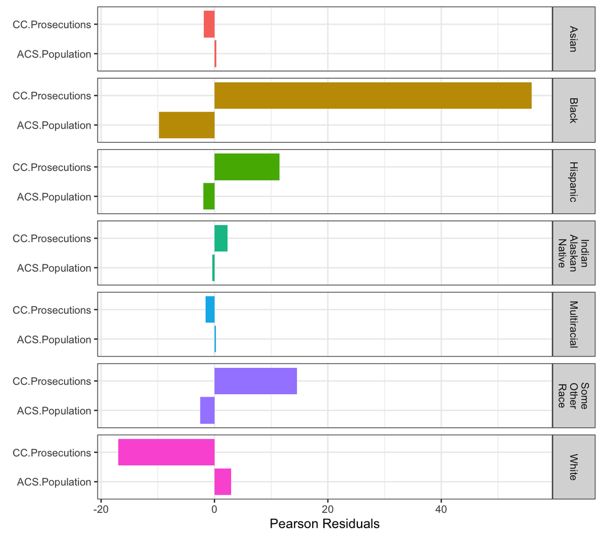

It is also possible to plot the contribution each count made towards the evidence that prosecution is not independent of race. The plot below shows the contribution as a percent of the overall evidence. Not surprisingly, this plot shows most of the contribution coming from the categories discussed above.

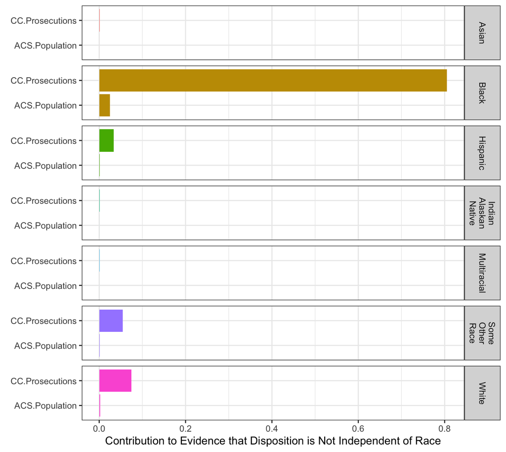

#### Residency

The difference in the racial makeup between the Golden Valley and the prosecuted populations outlined above points to the fact that 97% of prosecutions for low level driving offenses are for people living outside of Golden Valley. These people would be people driving through Golden Valley.

```
##                            Convicted Interim.Disposition Dismissed
## Non-Golden Valley Resident       349                  10       112
## Golden Valley Resident            19                   1         5
##                            No.Disposition
## Non-Golden Valley Resident            599
## Golden Valley Resident                 10
```

### Relationship Between Race and Disposition

To check whether disposition is dependent on race, we can use Fisher’s exact test. This test will evaluate how probable it is, given our data set, that disposition is dependent on race. Fisher’s exact test is used because it is appropriate for data sets with small counts lower than 5 some categories.

One thing to note is that the Unavailable category is used when the defendant doesn’t go to their trial, and the court is unable to record their race. It is fair to assume that this category probably has some distribution of races that is different from the general data set.

This is the data set:

```
##                       Convicted Interim.Disposition Dismissed No.Disposition
## White                        64                   1        29             73
## Black                        73                   3        43            276
## Multiracial                   2                   1         0             17
## Asian                         3                   1         1              7
## Indian Alaskan Native         2                   0         1              7
## Some Other Race               3                   1         5              7
## Hispanic                     25                   3         9             32
## Unavailable                 196                   1        29            190
```

For reference, here it is again, converted to proportions of prosecutions by race. For example, the table shows that the white conviction rate is 38%, but the multiracial conviction rate is just 10%. If their were no relationship between race and disposition, we would expect the values in each column to be approximately the same.

```
##                       Convicted Interim.Disposition Dismissed No.Disposition
## White                      0.38                0.01      0.17           0.44
## Black                      0.18                0.01      0.11           0.70
## Multiracial                0.10                0.05      0.00           0.85
## Asian                      0.25                0.08      0.08           0.58
## Indian Alaskan Native      0.20                0.00      0.10           0.70
## Some Other Race            0.19                0.06      0.31           0.44
## Hispanic                   0.36                0.04      0.13           0.46
## Unavailable                0.47                0.00      0.07           0.46
```

#### Results

```
##
##  Fisher's Exact Test for Count Data with simulated p-value (based on
##  1e+06 replicates)
##
## data:  low_level_driving_offenses_by_race
## p-value = 1e-06
## alternative hypothesis: two.sided
```

##### Analysis of Results

One way to understand the results is by looking at the Pearson Residuals of a similar test, chi-square test. Basically, this is done by estimating the number of dispositions we would see in each race, given their population, if there were no racial disparities in disposition. Comparing these estimates to the actual counts highlights areas where the data show disparities.

The plot below displays a statistical transformation of these differences to better capture differences between the actual and expected counts. If a bar is lower than zero, it means that category had fewer than the expected amount of cases, if a bar is higher, then it had more.

The salient features in this plot are:

1. The black conviction rate is abnormally low
2. The black no disposition rate is abnormally high
   - Taken with the low conviction rate this suggests more probation for black people than other races
3. The unavailable race group has a higher conviction rate than other groups
   - This group represents people who don’t have a trial, so this isn’t surprising since you usually lose your case if you don’t show up. But losing a case could put someone in any category besides Dismissed.
4. The Hispanic group has an unusually high rate of interim disposition
5. The white race group has an unusually high dismissed rate

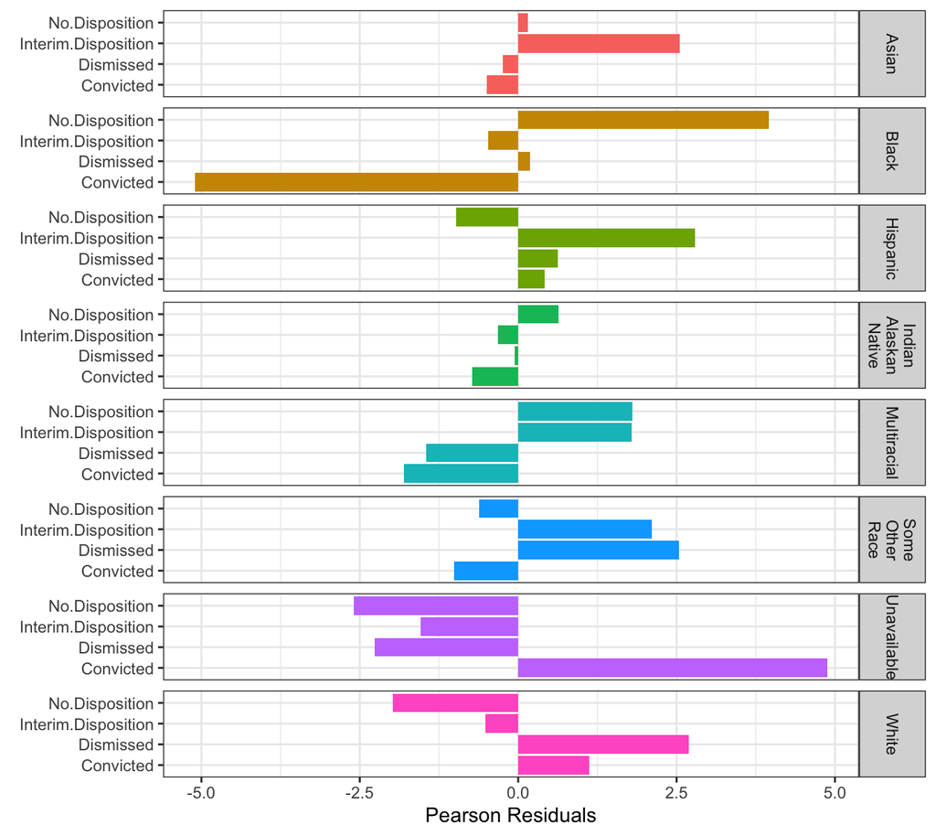

It is also possible to plot the contribution each count made towards the evidence that disposition is not independent of race. The plot below shows the contribution as a percent of the overall evidence. Not surprisingly, this plot shows most of the contribution coming from the categories enumerated above.

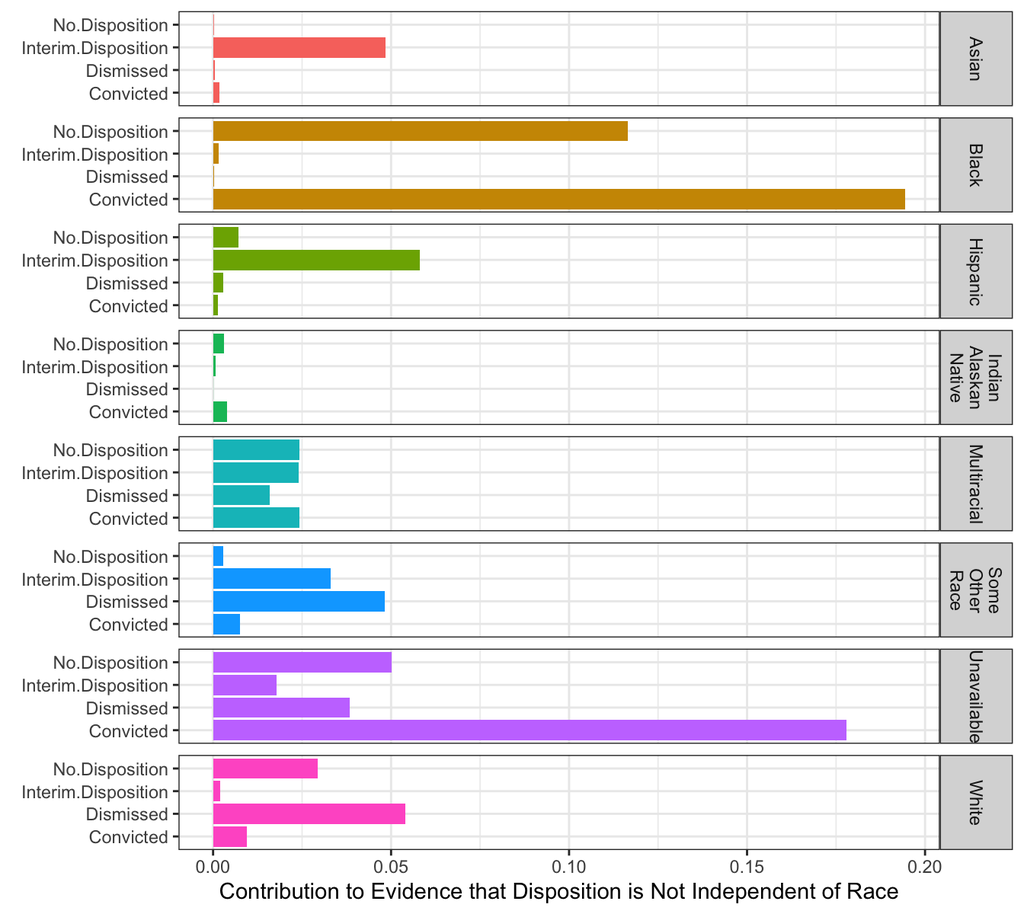